# Visualisering med `plotnine`

## Hvad er `plotnine`?

`plotnine` er en Python implementation af R pakken [ggplot2](https://ggplot2.tidyverse.org/). Pakken er baseret på en "grammar of graphics" tilgang til visualiesring; altså et "sprog" for at "italesætte" en visualisering.

Formålet med denne tilgang er at tillade en høj grad af tilpasning i visualiseringerne; både ift. indhold, udseende og kombination af graftyper.

**Fordele**

- Versatilt
- Tillader ufattelig mange graftyper (se fx https://www.r-graph-gallery.com/)
- Ensartet sprog uanset graftype

**Ulemper**

- Mængden af kode for at producere graf kan virke omfattende
- Overvældende mange muligheder
- Python-implementation kræver import af mange enkeltdele

## Introduktion til plotnine

```python
import pandas as pd

ess2018 = pd.read_csv("https://github.com/CALDISS-AAU/course_ddf/raw/master/datasets/ESS2018DK_subset.csv")
ess2018.head()
```

|  | idno | netustm | ppltrst | vote | prtvtddk | lvpntyr | tygrtr | gndr | yrbrn | edlvddk | eduyrs | wkhct | wkhtot | grspnum | frlgrsp | inwtm |
| --- | --- | --- | --- | --- | --- | --- | --- | --- | --- | --- | --- | --- | --- | --- | --- | --- |
| 0 | 5816 | 90.0 | 7.0 | Yes | SF Socialistisk Folkeparti - Socialist People'... | 1994 | 60 | Male | 1974 | Mellemlang videregående uddannelse af 3-4 års ... | 35.0 | 37.0 | 37.0 | 37000.0 | 35000.0 | 61.0 |
| 1 | 7251 | 300.0 | 5.0 | Yes | Dansk Folkeparti - Danish People's Party | 1993 | 40 | Female | 1975 | Faglig uddannelse (håndværk, handel, landbrug ... | 13.0 | 32.0 | 34.0 | 22000.0 | 30000.0 | 68.0 |
| 2 | 7887 | 360.0 | 8.0 | Yes | Socialdemokratiet - The Social democrats | 1983 | 55 | Male | 1958 | Lang videregående uddannelse. Kandidatuddannel... | 25.0 | 39.0 | 39.0 | 36000.0 | 42000.0 | 89.0 |
| 3 | 9607 | 540.0 | 9.0 | Yes | Alternativet - The Alternative | 1982 | 64 | Female | 1964 | Mellemlang videregående uddannelse af 3-4 års ... | 13.0 | 32.0 | 34.0 | 32000.0 | NaN | 50.0 |
| 4 | 11688 | NaN | 5.0 | Yes | Socialdemokratiet - The Social democrats | 1968 | 50 | Female | 1952 | Faglig uddannelse (håndværk, handel, landbrug ... | 2.0 | 37.0 | 37.0 | NaN | NaN | 77.0 |

### Import

Som alle andre pakker, skal plotnine importeres. I nedenstående importeres plotnine, og indstillingen for størrelsen af plot ændres:

```python
import plotnine
plotnine.options.figure_size = (12, 10)
```

Fordi `plotnine` er en konvertering af R-pakken `ggplot2`, er alle funktioner og metoder en del af `plotnine`. I stedet for at skulle skrive `plotnine` foran hver eneste metode/kommando, er det derfor en fordel at importere de dele, man skal bruge.

Det kan være svært at vide i starten præcist hvilke, man får brug for, så ofte vil det blive nødvendigt at gå tilbage og importere mere fra `plotnine`.

Her importeres de nødvendige "komponenter" for at danne et scatterplot:

```python
from plotnine import ggplot, aes, geom_point
```

Herunder dannes scatterplottet:

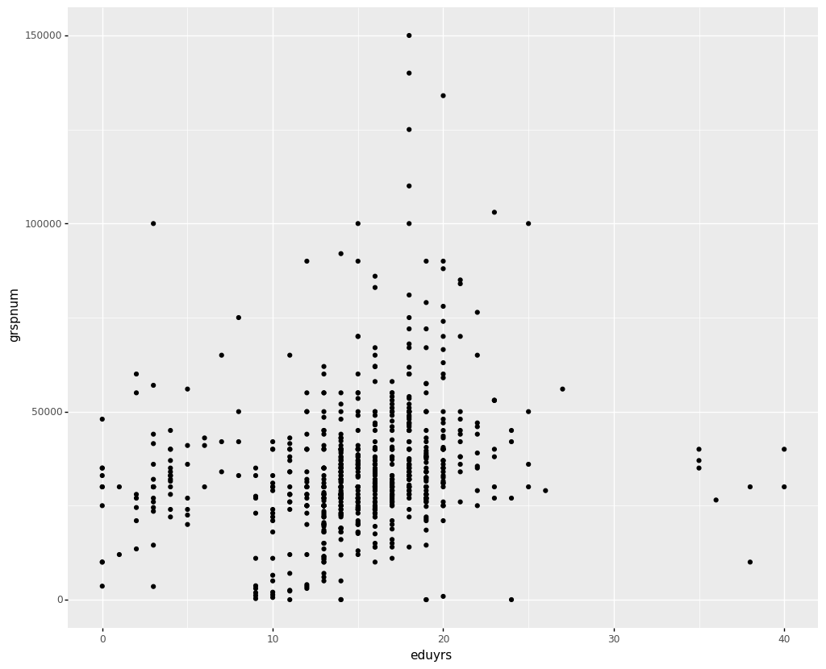

```python
ess2018_filt = ess2018.loc[ess2018['grspnum'] <= 200000, :] # Sorterer ekstreme værdier fra (max 200000 om måneden)

(ggplot(data = ess2018_filt, mapping = aes(x = 'eduyrs', y = 'grspnum'))
 + geom_point())
```

### Opbygning af et ggplot

Der er ufattelig mange måder at lave og tilpasse plots med ggplot/plotnine. Et ggplot følger dog som hovedregel denne skabelon:

```
ggplot(data = <DATA>, mapping = aes(<MAPPINGS>)) +
  <GEOM_FUNCTION>(mapping = aes(<MAPPINGS>))
```

- **ggplot**: Hovedfunktionen. Denne funktion indrammer, hvad der skal indgå i plottet. Funktionen `ggplot` indeholder i sig selv ikke information om, hvilken type plot det er. Dette angives med en geom funktion.
  - *data*: Det primære argument til ggplot er data, der skal bruges. Der forventes en pandas data frame.
- **mapping**: Argument. Her "mappes" oplysninger (aes: "aesthetics") i data til plottet. De primære mappings er `x` og `y`, som bestemmer akserne. Derudover findes også `colour`, `fill`, `shape`, `size`. Mapping angives altid med `aes(MAPPINGS)` (fx `aes(x = 'eduyrs', y = 'grspnum')`). Mapping kan både angives som argument i ggplot eller for den enkelte geom funktion. Forskellen er, om mappingen skal gælde for hele plottet eller blot specifikke geom funktioner.
- **GEOM_FUNCTION (fx geom_point)**: Plottingfunktion. Et "geom" er den geometriske størrelse brugt til at repræsentere data (søjer, linjer, boxplots, punkter osv.). Det er muligt at have flere geom funktioner (flere lag) i samme plot.
  - *mapping*: Alle geom funktioner i ggplot accepterer et mapping argument. Det er dog ikke alle aesthetics, der virker med alle geoms. Fx giver det ikke mening at mappe en variabel til y-aksen i et histogram, eller bestemme formen (shape) for en linje.

## Aesthetics i ggplot/plotnine

"Aesthetics" er som nævnt de forskellige oplysninger i data, som skal plottes på en eller anden måde. I det tidligere eksempel blev `x` og `y` fx brugt til at angive hhv. x-aksen og y-aksen i plottet:

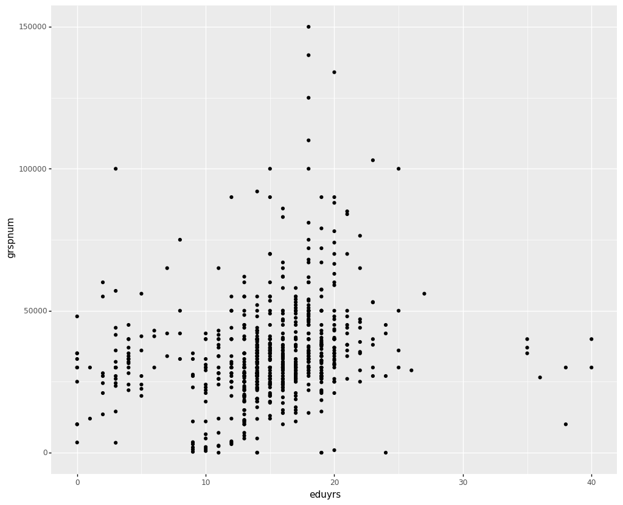

```python
(ggplot(data = ess2018_filt, mapping = aes(x = 'eduyrs', y = 'grspnum'))
 + geom_point())
```

#### Colour / fill

`colour` og `fill` bruges til at farvelægge efter en tredje variabel.

`colour` bruges typisk til at bestemme omridset af formerne, mens `fill` er farven, som formerne fyldes ud med.

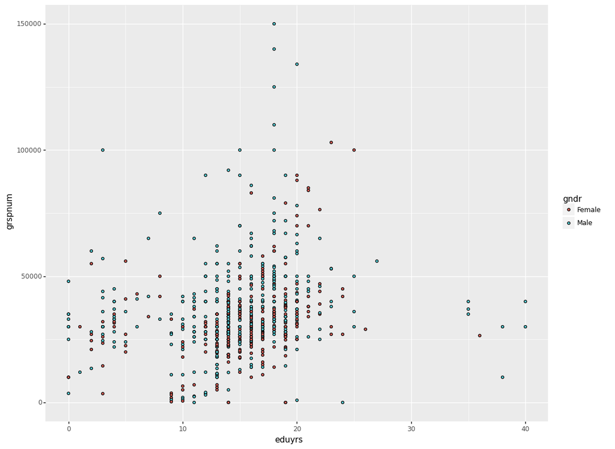

```python
(ggplot(data = ess2018_filt, mapping = aes(x = 'eduyrs', y = 'grspnum', fill = 'gndr'))
 + geom_point())
```

#### Shape

En `shape` aesthetic tildeler en unik figur/form til hver kategori i variablen:

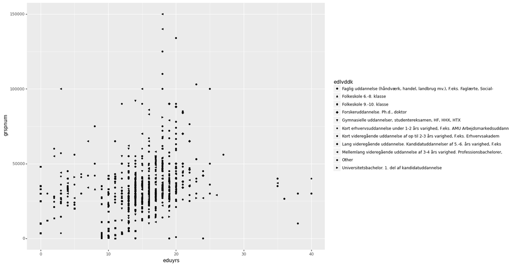

```python
(ggplot(data = ess2018_filt, mapping = aes(x = 'eduyrs', y = 'grspnum', shape = 'edlvddk'))
 + geom_point())
```

#### Size

En `size` aesthetic ændrer størrelsen på en figur/form afhængig af en værdien i en numerisk variabel:

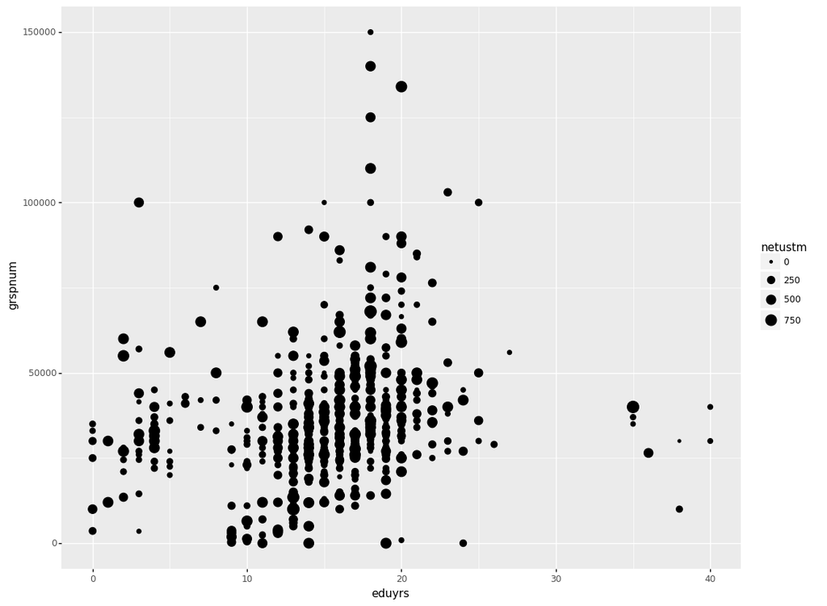

```python
(ggplot(data = ess2018_filt, mapping = aes(x = 'eduyrs', y = 'grspnum', size = 'netustm'))
 + geom_point())
```

### Aesthetics med "fast" værdi

De fleste aesthetics fungerer også som argumenter i de enkelte geom funktioner, hvor de kan angives uden for mapping argumentet for at sætte en fast værdi.

Bemærk fx at prikkerne i et scatterplot har sort kant, når man farvelægger med fill. Denne kan ændres ved blot at specificere en anden farve i et `colour` argument:

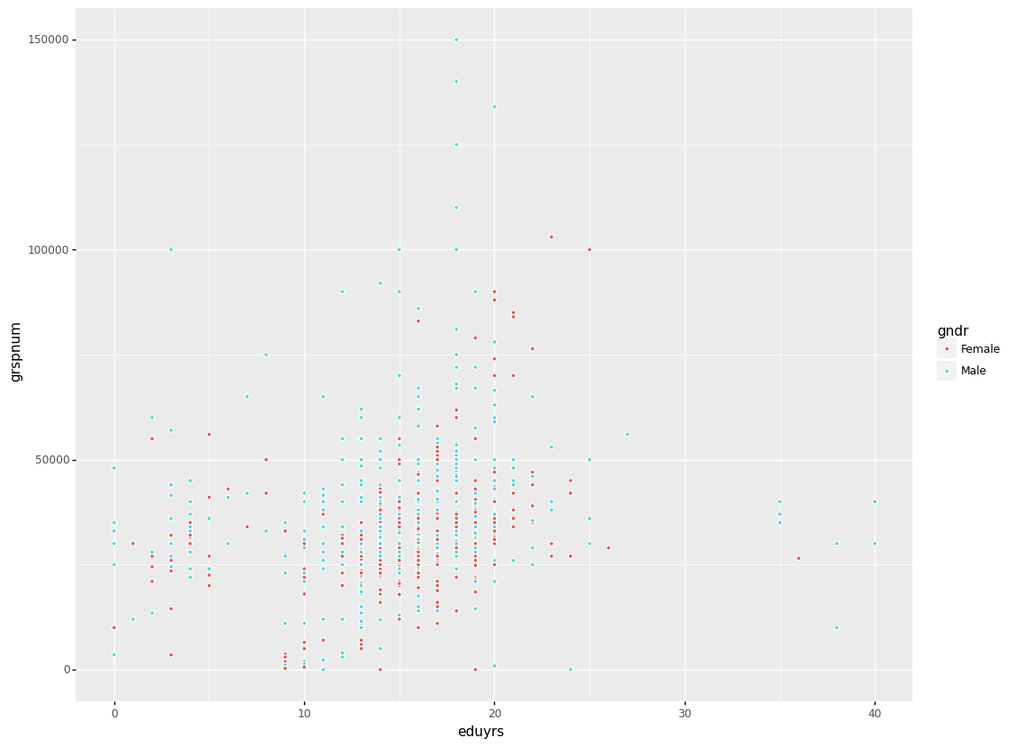

```python
(ggplot(data = ess2018_filt, mapping = aes(x = 'eduyrs', y = 'grspnum', fill = 'gndr'))
 + geom_point(colour = 'white'))
```

### Kombinering af aesthetics

Det er muligt at kombinere aesthetics i det samme plot. På den måde kan et plot indeholde mange forskellige funktioner:

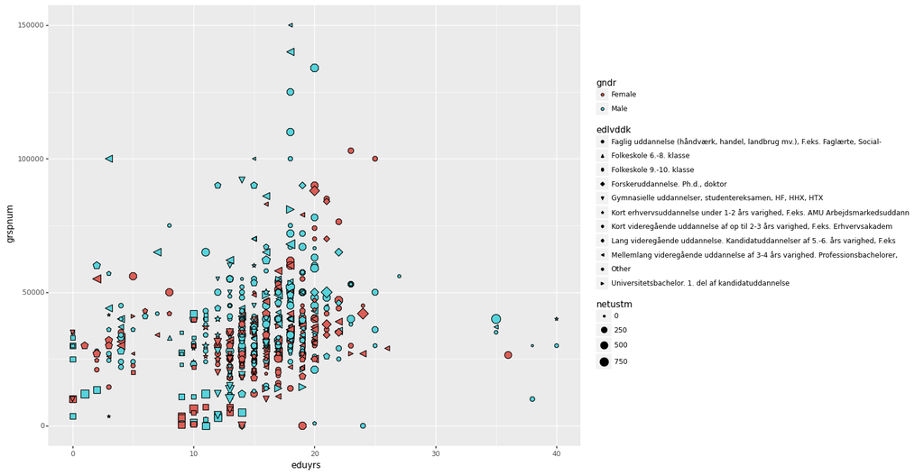

```python
(ggplot(data = ess2018_filt, mapping = aes(x = 'eduyrs', y = 'grspnum', fill = 'gndr', shape = 'edlvddk', size = 'netustm'))
 + geom_point())
```

## Geoms i ggplot/plotnine

Et "geom" er den graftype, som skal bruges til at plotte data. Navnet "geom" kommer af, at det refererer til den geometrisk form, som bruges til at repræsentere data (cirkel, søjle, linje osv.).

Når man har mappet aesthetics i starten af sin ggplot, kan man ofte nemt skifte sit geom ud (hvis altså det er kompatibelt med de samme aesthetics).

Eksemplerne indtil nu har brugt `geom_point()` til at danne et scatterplot, men samme data kunne også plottes som en kurve/trendlinje med `geom_smooth()`:

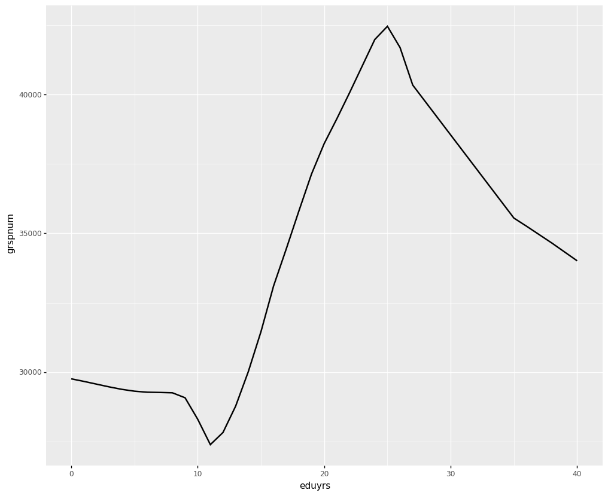

```python
from plotnine import geom_smooth

(ggplot(data = ess2018_filt, mapping = aes(x = 'eduyrs', y = 'grspnum'))
 + geom_smooth())
```

Det er også muligt at kombinere flere geoms i den samme visualisering:

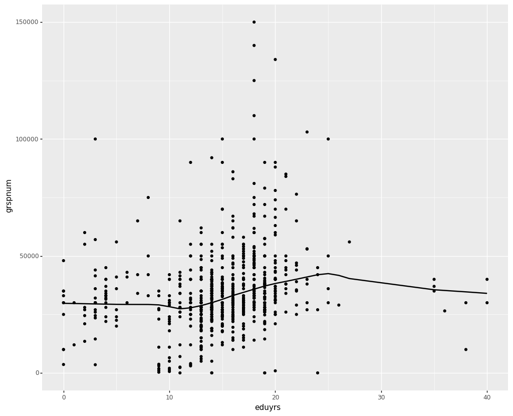

```python
(ggplot(data = ess2018_filt, mapping = aes(x = 'eduyrs', y = 'grspnum'))
 + geom_point()
 + geom_smooth())
```

Grafer med flere geoms kan have forskellige mappings:

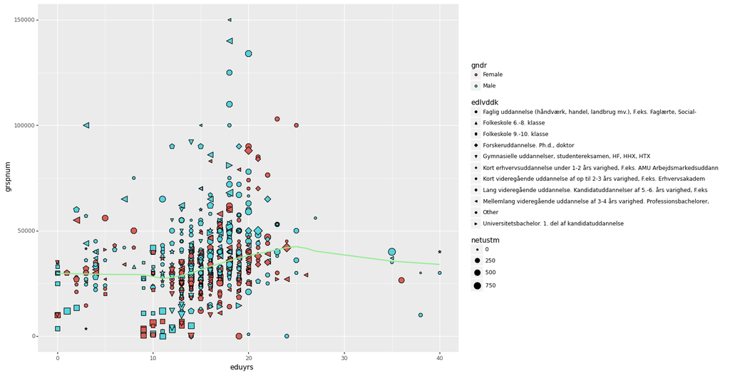

```python
(ggplot(data = ess2018_filt, mapping = aes(x = 'eduyrs', y = 'grspnum'))
 + geom_point(mapping = aes(fill = 'gndr', shape = 'edlvddk', size = 'netustm'))
 + geom_smooth(colour = 'lightgreen'))
```

## Tilpasning af plot

Ens graf kan tilpasses på ufattelig mange måder. Her gennemgås nogen af de mest basale ændringer, som man kan foretage:

### Labels

Labels kan tilføjes hvor hver aesthetic, som man har i grafen (akserne, farvelægningerne osv.):

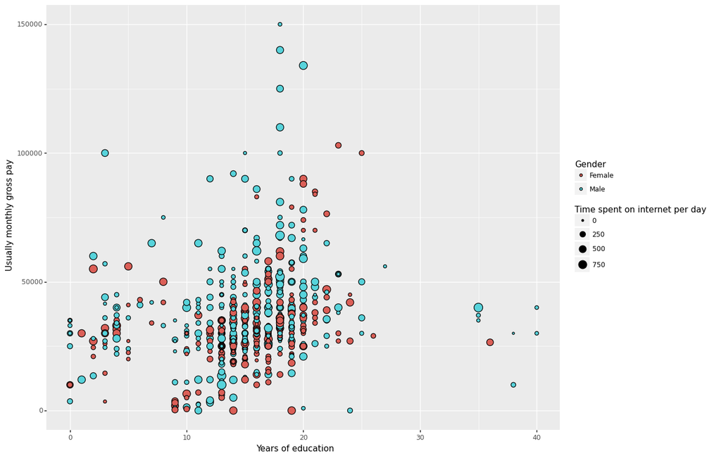

```python
from plotnine import labs

(ggplot(data = ess2018_filt, mapping = aes(x = 'eduyrs', y = 'grspnum', fill = 'gndr', size = 'netustm'))
 + geom_point()
 + labs(x = 'Years of education', y = 'Usually monthly gross pay', fill = 'Gender', size = 'Time spent on internet per day'))
```

## Titel

Titel kan tilføjes med `ggtitle()` eller under `labs()`.

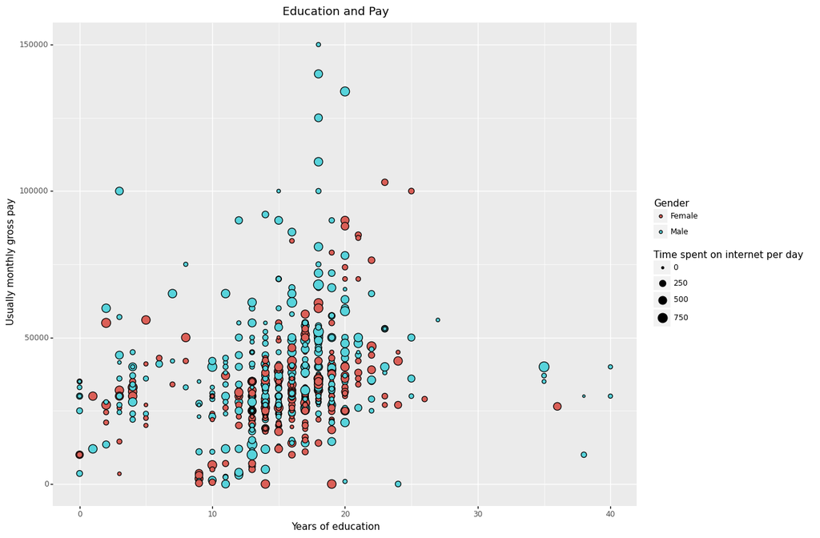

```python
from plotnine import ggtitle

(ggplot(data = ess2018_filt, mapping = aes(x = 'eduyrs', y = 'grspnum', fill = 'gndr', size = 'netustm'))
 + geom_point()
 + labs(x = 'Years of education', y = 'Usually monthly gross pay', fill = 'Gender', size = 'Time spent on internet per day')
 + ggtitle('Education and Pay'))
```

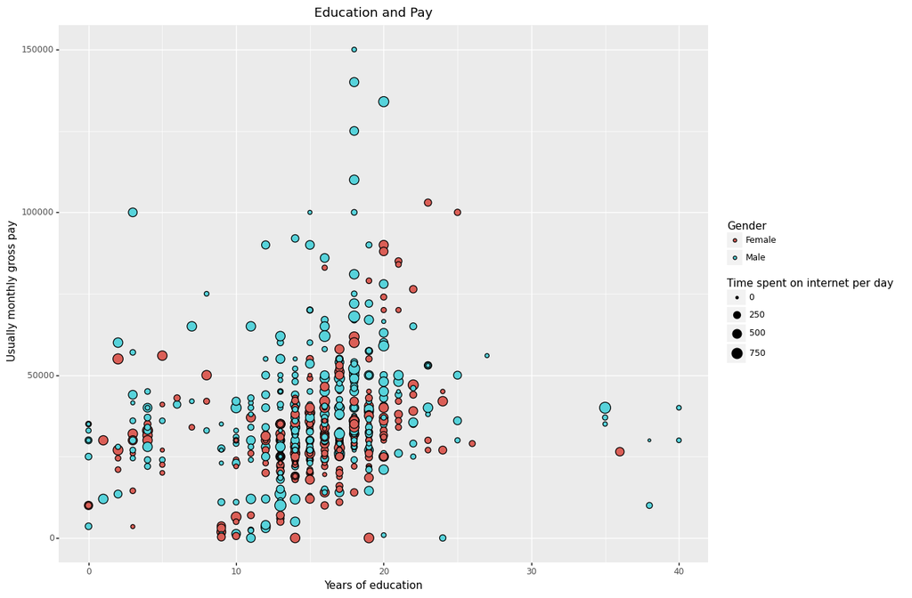

```python
(ggplot(data = ess2018_filt, mapping = aes(x = 'eduyrs', y = 'grspnum', fill = 'gndr', size = 'netustm'))
 + geom_point()
 + labs(title = 'Education and Pay', x = 'Years of education', y = 'Usually monthly gross pay', fill = 'Gender', size = 'Time spent on internet per day'))
```

## Legend

Tegnforklaringen (legend) bruger værdierne fra data. Hvis ikke man vil ændre værdierne i data, kan man ændre dem direkte gennem den passende scale-funktion:

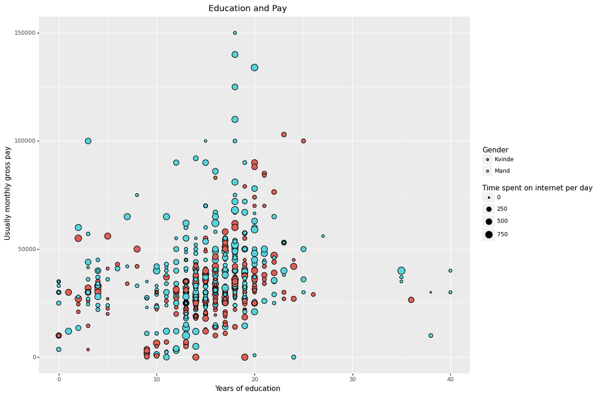

```python
from plotnine import scale_fill_discrete

(ggplot(data = ess2018_filt, mapping = aes(x = 'eduyrs', y = 'grspnum', fill = 'gndr', size = 'netustm'))
 + geom_point()
 + labs(x = 'Years of education', y = 'Usually monthly gross pay', fill = 'Gender', size = 'Time spent on internet per day')
 + scale_fill_discrete(labels = ['Kvinde', 'Mand'])
 + ggtitle('Education and Pay'))
```

## Temaer

Der findes en række standardtemaer (https://plotnine.readthedocs.io/en/stable/api.html#themes). Derudover er det også muligt at specificere sit eget. Herunder bruges "theme_classic":

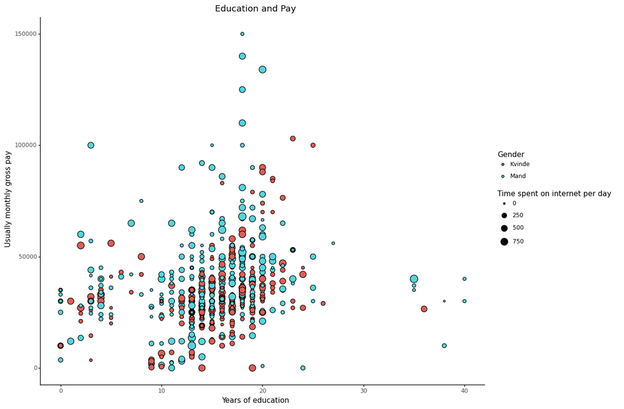

```python
from plotnine import theme_classic

(ggplot(data = ess2018_filt, mapping = aes(x = 'eduyrs', y = 'grspnum', fill = 'gndr', size = 'netustm'))
 + geom_point()
 + labs(x = 'Years of education', y = 'Usually monthly gross pay', fill = 'Gender', size = 'Time spent on internet per day')
 + scale_fill_discrete(labels = ['Kvinde', 'Mand'])
 + ggtitle('Education and Pay')
 + theme_classic())
```

# ØVELSE 1: VISUALISERING MED PLOTNINE

- Brug `ggplot()` og `geom_bar()` til at danne et søjediagram over fordelingen af stemmer på de forskellige partier ("prtvtddk").
- Inddel optællingerne i køn ("gndr") ved at mappe det til et `fill` aesthetic.
- `geom_bar()` danner som standard en "stacked bar chart" . Dette kan ændres med argumentet "position". Prøv at skifte mellem "stack", "dodge", "fill" som værdi for "position"-argumentet.

**Bonus**

- Tilføj mere sigende titler og labels til din graf